# Homework 2

[Assignment Details](https://github.com/arahuja/GADS4/wiki/Regression-Assignment)

**Update:** Fixing the NA problem, and completely reworked how the location tree is handled.

```r
library(plyr)
library(knitr)
library(DAAG)
library(tm)
library(foreach)
setwd("~/Documents/GeneralAssembly/GADS4/hw2/")
```

```r
data <- read.csv("~/Documents/GeneralAssembly/arun/GADS4/data/kaggle_salary/train.csv")
```

Taken from [kaggle site](http://www.kaggle.com/c/job-salary-prediction/data).

- ID - key of the row, should be unique
- Title - Title of the job ad
- FullDescription - body of job add. Numerics have been replaced by astericks to remove salary info, may have removed other numbers.
- LocationRaw - Location of job
- LocationNormalized - Adzuna's interpretaion of the location
- ContractType - Full time (2978), part time(578), or blank (6444)
- ContractTime - contract (605), permanent(4132), or blank (5263)
- Company - employer name
- Category - 30 standard jobs as defined by adzuna
- SalaryRaw - text of salary from employer
- SalaryNormalized - value of salary - *Predict this*
- SourceName - website where job was advertised

We're prdiciting SalaryNormalized, so let's check it out a little:

```r
summary(data$SalaryNormalized)
```

```
##    Min. 1st Qu.  Median    Mean 3rd Qu.    Max.
##    5180   20600   27500   31500   37500  173000
```

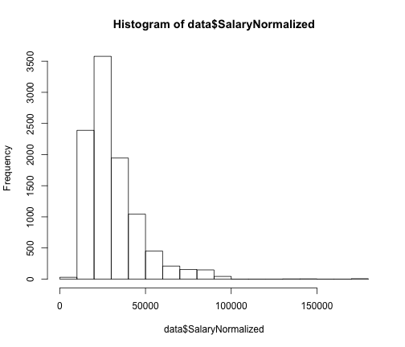

```r
hist(data$SalaryNormalized)
```

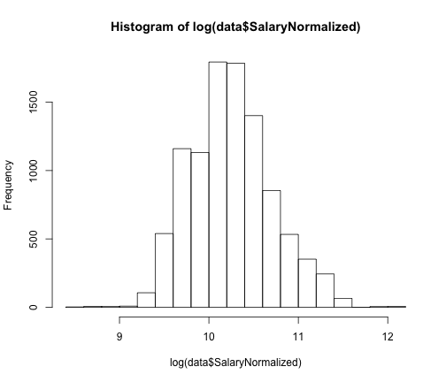

```r
hist(log(data$SalaryNormalized))
```

SalaryNormalized is pretty skewed, but log(SalaryNormalized) looks pretty gaussian, so let's predict that instead. Also, let's ditch FullDescription since we're not going to use that, at least until the very end of the assignment

```r
data$LogSalary <- log(data$SalaryNormalized)
data$FullDescription <- NA
```

### Problem 1: Split the data into training and test sets.

I'll do 90/10 train/validate. I liked Aaron's fold field that he showed in class.

```r
m = nrow(data)  # number of rows
data$fold <- sample(1:10, m, replace = T)

n = 1
test <- data[data$fold == n, ]
train <- data[data$fold != n, ]
```

### Problem 2: Build a simple linear regression using the available categorical variables.

Before doing the regression, let's define a couple functions to make life cleaner:

```r
mae <- function(values, predictions) {
    return(mean(abs(values - predictions), na.rm = T))
}

hw2.cv.lm <- function(form, frame) {
    r.squares <- c()
    train_mae <- c()
    test_mae <- c()
    for (i in 1:max(frame$fold)) {
        train <- frame[frame$fold != i, ]
        test <- frame[frame$fold == i, ]

        model <- lm(form, data = train)

        r.squares <- c(r.squares, summary(model)$r.squared)
        trainPredictions <- exp(predict(model, train))
        testPredictions <- exp(predict(model, test))

        train_mae <- c(train_mae, mae(train$SalaryNormalized, trainPredictions))
        test_mae <- c(test_mae, mae(test$SalaryNormalized, testPredictions))
    }
    cat("Mean R.Squared: ", mean(r.squares))
    cat(" Mean Training MAE: ", mean(train_mae))
    cat(" Mean Test Set MAE: ", mean(test_mae))
    return(model)
}

reduceFactors <- function(frame, field, newname, number) {
    factorsToKeep <- names(sort(summary(frame[, c(field)]), decreasing = T)[1:number])
    temp <- frame[, c(field)]
    levels(temp) <- c(levels(temp), " ")
    withNAs <- factor(temp, levels = factorsToKeep)
    temp[is.na(withNAs)] <- " "
    woNAs <- factor(temp)
    frame[, c(newname)] <- woNAs
    return(frame)
}
```

Without some text parsing, title, full description, and LocationRaw are useless. Company has 10% the number of values as we have jobs, and using the raw company name seems limiting. You could probably do something fun with classifying the employer by name, but that's for another time (and category probably already includes some of that information) ContractTime and ContractType worry me since over half of the jobs have blanks for these fields, but there is some additional info for some of the listings. Category, LocationNormalized, and SourceName look like the best places to start, even if category and LocationNormalized have Adzuna's intrepretation built in.

```r
form <- LogSalary ~ Category + LocationNormalized + SourceName
model <- hw2.cv.lm(form, data)
```

```
## Error: factor LocationNormalized has new levels Argyll & Bute, Arundel,
## Ashington, Bacup, Ballymena, Bilston, Bishop Auckland, Brigg, Cramlington,
## Crediton, Dymock, Egremont, Esher, Fradley Park, Glenrothes, Godstone,
## Heanor, Henlow, Liphook, Llandrindod Wells, Melksham, Oldbury, Oxford
## Airport, Paris Island Little, Pembroke, Prudhoe, Radstock, Redcar, Saffron
## Walden, Shaftesbury, Southend, Stanford-Le-Hope, Stone, Thorpe St. Andrew,
## Thurso, Tidworth, Totnes, Uttoxeter, Wareham, Wokingham
```

This regression takes too long on the 10k set, and LocationNormalized has too many levels (there are locations in the test set that don't appear in the traing set.) Let's ditch LocationNormalized for now and go back to just Category and just SourceName

```r
form <- LogSalary ~ Category
model <- hw2.cv.lm(form, data)
```

```
## Mean R.Squared:  0.1832 Mean Training MAE:  10143 Mean Test Set MAE:  10170
```

The category factors alone are significant, but don't explain much of the variance, hence the low R squared and the relatively high MAE for both the training and test sets. Now just SourceName:

```r
form <- LogSalary ~ SourceNameReduced
data <- reduceFactors(data, "SourceName", "SourceNameReduced", 20)
model <- hw2.cv.lm(form, data)
```

```
## Mean R.Squared:  0.1944 Mean Training MAE:  10037 Mean Test Set MAE:  10056
```

The test sets have some SourceName that aren't in the training set, blerg. I set those to ' ' and had predict ignore them, and mae() ignores NA as well.

So SourceName does marginally better than Category, but has issues with having enough data in each category. This could improve with more data.

Let's check out ContractType and ContractTime

```r
form <- LogSalary ~ ContractType + ContractTime
model <- hw2.cv.lm(form, data)
```

```
## Mean R.Squared:  0.1025 Mean Training MAE:  10565 Mean Test Set MAE:  10568
```

These are crap for R squared, but the coefficients are significant, so may be worth including with category. Soooo, let's see what we have with category and contracttime/type

```r
form <- LogSalary ~ Category + ContractType + ContractTime
model <- hw2.cv.lm(form, data)
```

```
## Mean R.Squared:  0.238 Mean Training MAE:  9766 Mean Test Set MAE:  9800
```

Getting better, but 9.7k mean absolute error is pretty crap when the mean is 30k. Last attempt for This problem: Category, ContractType/Time, and SourceName, and we'll ignore the mismatched SourceNames for now.

```r
data <- reduceFactors(data, "Category", "CategoryReduced", 15)
form <- LogSalary ~ SourceNameReduced + Category + ContractTime + ContractTime
model <- hw2.cv.lm(form, data)
```

```
## Mean R.Squared:  0.2451 Mean Training MAE:  9736 Mean Test Set MAE:  9786
```

Well, this one has the best R-Squared of the fast models, and the training and test MAEs are on par with the Category and Type/Time model, but they still aren't impressive.

I just re-read the instructions and realize I forgot to try interaction terms. Here it goes

```r
form <- LogSalary ~ SourceNameReduced + Category + ContractTime + ContractType +
    CategoryReduced:ContractTime + CategoryReduced:ContractType + ContractType:ContractTime
model <- hw2.cv.lm(form, data)
```

```
## Mean R.Squared:  0.303 Mean Training MAE:  9326 Mean Test Set MAE:  9435
```

You'll notice that for the interaction terms I used CategoryReduced instead of Category. This pairs up just the top 15 Categories instead of doing the full set. I found this to be much faster to run, and comparable to using many Categories.

The measures are all better, but we're starting to see a separation in the training and the test set MAEs. Maybe this is evidence of overfitting? I'll be sure to try this model with the larger datasets and see if that helps.

### Problem 3: Install DAAG

Try out cv.lm to see about improving the models

```r
library("DAAG")
form <- formula(LogSalary ~ SourceNameReduced + Category + ContractType + ContractTime +
    CategoryReduced:ContractTime + CategoryReduced:ContractType)
test <- cv.lm(df = data, form.lm = form, m = 3, printit = F)
```

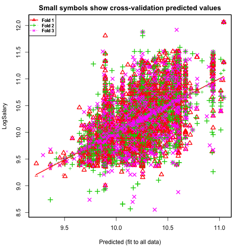

```r
# ms = 0.148
form <- formula(LogSalary ~ SourceNameReduced + Category + ContractType + ContractTime +
    CategoryReduced:ContractTime + CategoryReduced:ContractType + ContractType:ContractTime)
test <- cv.lm(df = data, form.lm = form, m = 3, printit = F)
```

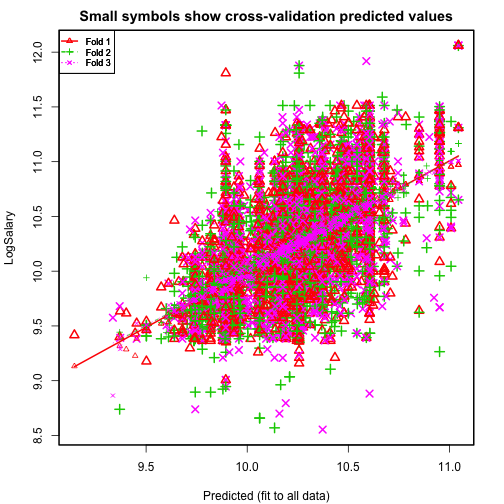

```r
# ms = 0.148
form <- formula(LogSalary ~ SourceNameReduced + Category + ContractType + ContractTime)
test <- cv.lm(df = data, form.lm = form, m = 3, printit = F)
```

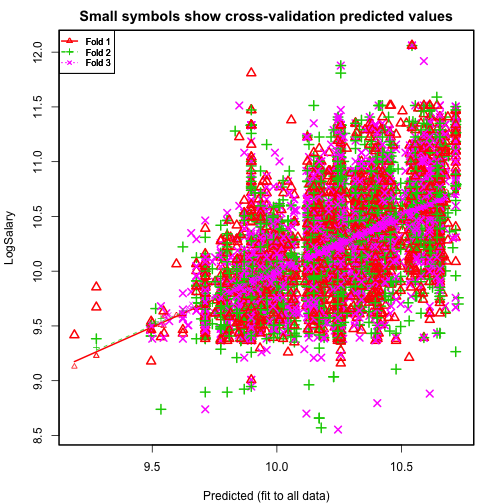

```r
# ms = 0.152
```

It's confusing to use, but I think this is showing that the interaction terms do improve the mean square error (ms), but that the ContractType:ContractTime term doesn't seem to be helping.

The plots nice, but I don't like that I don't have access to the coefficients of the models.

### Problem 4: Merge Location_Tree.csv on to your dataset

I'm not sure if turning the Location Tree into a data frame was supposed to be complicated, but I found that the rows are different lengths, so before converting the file into a data frame I had to set the length of each row to 5.

I could imagine a different approach could be looping through each LocationNormalized, finding a matching field in the location tree and filling in the location fields that way…

**Update:** Changing this to my imagined way. I think it will be simpler in the end.

```r
location_tree <- read.csv("~/Documents/GeneralAssembly/arun/GADS4/data/kaggle_salary/Location_Tree.csv",
    stringsAsFac = F)

location_list <- strsplit(location_tree[, 1], "~")
```

I'm going to define the Location Tree as Country > Region > SubRegion > SubSubRegion > MicroRegion

The new approach is to loop through the location_list, see if LocationNormalized matches any of the fields and if so, grab the Region and SubRegion field and put them in the dataframe.

I think there is some semi-intelligent way of doing this with R's list-apply stuff.

**Q:** Are functions in the global namespace? If I use functions in functions, does everything behave properly?

```r
fixlength <- function(x) {
    flat <- unlist(x)
    length(flat) <- 5
    flat[is.na(flat)] <- " "
    return(flat)
}

# I'm not sure this is necessary with the new non-merge approach, but I'm
# pretty sure it won't hurt either.

location_list <- llply(location_list, fixlength)
location_matrix <- matrix(unlist(location_list), ncol = 5, byrow = T)

# Since I'm not using merge anymore, I think keeping the locations in a
# list is better. loc_frame <-
# data.frame(matrix(unlist(location_list),nrow=31762,byrow=T))
# colnames(loc_frame)=c('Country','Region','SubRegion','SubSubRegion','MicroRegion')
```

Now to merge the locations and the data. It's a little complicated because LocationNormalized is not always the same level in the location tree.

```r
findRegions <- function(loc) {
    # location_matrix must be globally defined
    loc_rows <- nrow(location_matrix)
    indx <- grep(paste0("^", loc, "$"), location_matrix)
    if (length(indx) > 0) {
        return(location_matrix[indx[1]%%loc_rows, 2:3])
    } else return(c(" ", " "))
}

# Tests

findRegions("Shadwell")
```

```
## [1] "London"      "East London"
```

```r
findRegions("Victoria Park")
```

```
## [1] "London"      "East London"
```

```r
findRegions("North Landan")
```

```
## [1] " " " "
```

```r
findRegions("Angel")
```

```
## [1] "London"       "North London"
```

```r
# Works for me. Returns a single pair of values, returns blanks if it
# doesn't find a location. Now to wrap it up in lapply

# data <-
# llply(data$LocationNormalized,findRegions,.progress=create_progress_bar('text'))
```

That is brutally slow by my impatient standards. Going to try unwrapping it into a loop.

```r
# loc_rows <- nrow(location_matrix) Region <- character(length =
# nrow(data)) SubRegion <- character(length = nrow(data)) for (i in
# 1:nrow(data)){ indx <-
# grep(paste0('^',data$LocationNormalized[i],'$'),location_matrix) if
# (length(indx) > 0) { row_indx <- indx[1] %% loc_rows if (row_indx == 0)
# row_indx <- loc_rows Region[i] <- location_matrix[row_indx,2]
# SubRegion[i] <- location_matrix[row_indx,3] } else { Region[i] <- ' '
# SubRegion[i] <- ' ' } }

# data$Region <- factor(Region) data$SubRegion <- factor(SubRegion)
```

Still brutally slow. This is something to do in another language. I'm going to leave it here as an example of what you *could* do, but if I have the inclination, I'll write a script to produce a mergable table…

```
cat Location_Tree.csv | sed 's/~/,/g' | sed 's/"//g' > Location_Tree2.csv
awk -f buildMergable.awk Location_Tree2.csv |sort -u -t , -k 1,1 >mergableTable.csv
echo UK,undef,undef,1 >> mergableTable.csv
```

Boom. After banging my head against it a little bit, it makes the most sense to ignore the train.csv files and instead just build a file of all possible locationNormalized values. This is blazing fast compared to anything else I tried. The awk script runs through the Location_Tree file once, outputing up to 5 times the lines of the tree, although actually it's about 4 times. That output is sorted and uniqued on the first field (what we'll call LocationNormalized). This isn't perfect because there are degeneracies - some Locations occur in multiple regions.

I added a depth field just for fun, it specifies how 'deep' down the location tree that location is.

```r
# cat Location_Tree.csv | sed 's/~/,/g' | sed 's/'//g' >
# Location_Tree2.csv awk -f buildMergable.awk Location_Tree2.csv |sort -u
# -t , -k 1,1 >mergableTable.csv

location_df <- read.csv("~/Documents/GeneralAssembly/GADS4/hw2/mergableTable.csv",
    head = F)
colnames(location_df) <- c("LocationNormalized", "Region", "SubRegion", "depth")

data <- merge(data, location_df, by = "LocationNormalized", all.x = T)
# Need to ditch the NAs before using the merged locations. There are only
# 8.

data$depth[is.na(data$depth)] = 0
data$Region[is.na(data$Region)] = "undef"
data$SubRegion[is.na(data$SubRegion)] = "undef"
```

**SUCCESS!**

Now for much more exiciting models, let's use location!

```r
data <- reduceFactors(data, "Region", "RegionReduced", 12)
data$RegionReduced[data$RegionReduced == " "] <- "undef"
data <- reduceFactors(data, "SubRegion", "SubRegionReduced", 20)
data$SubRegionReduced[data$SubRegionReduced == " "] <- "undef"
form <- LogSalary ~ RegionReduced + SubRegionReduced + SourceNameReduced + Category +
    ContractTime + ContractType + CategoryReduced:ContractTime + CategoryReduced:ContractType +
    ContractType:ContractTime
model <- hw2.cv.lm(form, data)
```

```
## Mean R.Squared:  0.3389 Mean Training MAE:  9036 Mean Test Set MAE:  9164
```

Looking better! Down to ~9.1k MAE in both the training and the test set.

Before trying out glmnet, I was to try the next larger dataset. This also allows me to regroup all the processing of the data datafram in one place.

```r
bigger <- read.csv("~/Documents/GeneralAssembly/arun/GADS4/data/kaggle_salary/train_50k.csv")
bigger$LogSalary <- log(bigger$SalaryNormalized)
bigger$FullDescription <- NA
bigger$fold <- sample(1:10, nrow(bigger), replace = T)
bigger <- reduceFactors(bigger, "SourceName", "SourceNameReduced", 20)
bigger <- reduceFactors(bigger, "Category", "CategoryReduced", 20)
## Locations
bigger <- merge(bigger, location_df, by = "LocationNormalized", all.x = T)
sum(is.na(bigger$depth))
```

```
## [1] 100
```

```r
bigger$depth[is.na(bigger$depth)] = 0
bigger$Region[is.na(bigger$Region)] = "undef"
bigger$SubRegion[is.na(bigger$SubRegion)] = "undef"

bigger <- reduceFactors(bigger, "Region", "RegionReduced", 12)
bigger$RegionReduced[bigger$RegionReduced == " "] <- "undef"
bigger <- reduceFactors(bigger, "SubRegion", "SubRegionReduced", 20)
bigger$SubRegionReduced[data$SubRegionReduced == " "] <- "undef"

form <- LogSalary ~ RegionReduced + SubRegionReduced + Category + SourceNameReduced +
    ContractTime + ContractType + CategoryReduced:ContractTime + CategoryReduced:ContractType +
    ContractType:ContractTime
model <- hw2.cv.lm(form, bigger)
```

```
## Mean R.Squared:  0.3988 Mean Training MAE:  9956 Mean Test Set MAE:  9986
```

This is a little awkward, the MAE is getting larger with the larger dataset, ~10k for the 50k.

### Problem 5: Using the GLMnet package, try glm and cv.glmnet to see if you can build a better model.

Let's try just replacing lm with glm:

```r
hw2.cv.glm <- function(form, data) {
    r.squares <- c()
    train_mae <- c()
    test_mae <- c()
    for (i in 1:max(data$fold)) {
        train <- data[data$fold != i, ]
        test <- data[data$fold == i, ]

        model <- glm(form, data = train)

        r.squares <- c(r.squares, summary(model)$r.squared)
        trainPredictions <- exp(predict(model, train))
        testPredictions <- exp(predict(model, test))

        train_mae <- c(train_mae, mae(train$SalaryNormalized, trainPredictions))
        test_mae <- c(test_mae, mae(test$SalaryNormalized, testPredictions))
    }
    cat(" Mean Training MAE: ", mean(train_mae))
    cat(" Mean Test Set MAE: ", mean(test_mae))
    return(model)
}

form <- LogSalary ~ RegionReduced + SubRegionReduced + SourceNameReduced + Category +
    ContractTime + ContractType + CategoryReduced:ContractTime + CategoryReduced:ContractType +
    ContractType:ContractTime
model <- hw2.cv.glm(form, data)
```

```
##  Mean Training MAE:  9036 Mean Test Set MAE:  9164
```

Same result as the lm revsion as expected, it happened, cool. Now let's get our regularization on.

```r
library(glmnet)
form <- LogSalary ~ RegionReduced + SubRegionReduced + SourceNameReduced + Category +
    ContractTime + ContractType + CategoryReduced:ContractTime + CategoryReduced:ContractType +
    ContractType:ContractTime

train_mae <- c()
test_mae <- c()
for (i in 1:max(data$fold)) {
    train <- data[data$fold != i, ]
    test <- data[data$fold == i, ]
    m <- model.frame(form, train)
    mtest <- model.frame(form, test)
    x <- model.matrix(form, data = m)
    y <- matrix(m$LogSalary)
    model <- glmnet(x, y)

    testx <- model.matrix(form, data = mtest)
    trainPredictions <- exp(predict(model, x, s = 5e-04))
    testPredictions <- exp(predict(model, testx, s = 5e-04))

    train_mae <- c(train_mae, mae(exp(m$LogSalary), trainPredictions))
    test_mae <- c(test_mae, mae(exp(mtest$LogSalary), testPredictions))
}
mean(train_mae)
```

```
## [1] 9049
```

```r
mean(test_mae)
```

```
## [1] 9169
```

Looks cool. Now to use cv.glmnet to get the best value of lambda and then try it all on a larger set.

```r
form <- LogSalary ~ RegionReduced + SourceNameReduced + CategoryReduced + ContractTime +
    ContractType + CategoryReduced:ContractTime + CategoryReduced:ContractType +
    ContractType:ContractTime + RegionReduced:CategoryReduced

hw2.cv.glmnet <- function(form, frame, folds) {
    train_mae <- c()
    test_mae <- c()
    for (i in 1:folds) {
        train <- frame[frame$fold != i, ]
        test <- frame[frame$fold == i, ]

        m <- model.frame(form, train)
        x <- model.matrix(form, data = m)
        y <- matrix(train$LogSalary)

        model <- cv.glmnet(x, y, type.measure = "mae")

        mtest <- model.frame(form, test)
        testx <- model.matrix(form, data = mtest)

        trainPredictions <- exp(predict(model, x, s = "lambda.min"))
        testPredictions <- exp(predict(model, testx, s = "lambda.min"))
        train_mae <- c(train_mae, mae(exp(train$LogSalary), trainPredictions))
        test_mae <- c(test_mae, mae(exp(test$LogSalary), testPredictions))
    }
    print(train_mae)
    cat(" Mean Training MAE: ")
    print(mean(train_mae))
    print(test_mae)
    cat(" Mean Test Set MAE: ")
    print(mean(test_mae))
    return(model)
}

model <- hw2.cv.glmnet(form, data, 10)
```

```
##  [1] 8968 9041 8941 8978 8987 9014 8968 8995 8978 9011
##  Mean Training MAE: [1] 8988
##  [1] 9311 8875 9693 9252 8990 8977 9559 9194 9196 8888
##  Mean Test Set MAE: [1] 9194
```

Let's try on the larger dataset

```r
i <- 2
train <- bigger[bigger$fold != i, ]
test <- bigger[bigger$fold == i, ]

m <- model.frame(form, train)
x <- model.matrix(form, data = m)
y <- matrix(m$LogSalary)

model <- cv.glmnet(x, y, type.measure = "mae")

mtest <- model.frame(form, test)
testx <- model.matrix(form, data = mtest)

trainPredictions <- exp(predict(model, x, s = "lambda.min"))
testPredictions <- exp(predict(model, testx, s = "lambda.min"))

mae(exp(m$LogSalary), trainPredictions)
```

```
## [1] 9936
```

```r
mae(exp(mtest$LogSalary), testPredictions)
```

```
## [1] 10137
```

Hmph. Still 10k.

### Problem 6: Now let's try adding some text features

```r
library("tm")

src <- DataframeSource(data.frame(data$Title))
c <- Corpus(src)
dtm <- DocumentTermMatrix(c, control = list(termFreq = list(stopwords = TRUE)))
dtmcols <- colnames(dtm)

analysts <- rowSums(as.matrix(dtm[, grep("analy", dtmcols, ignore.case = T)]))
engineers <- rowSums(as.matrix(dtm[, grep("engine", dtmcols, ignore.case = T)]))
software <- rowSums(as.matrix(dtm[, grep("soft", dtmcols, ignore.case = T)]))
restaurant <- rowSums(as.matrix(dtm[, grep("restau", dtmcols, ignore.case = T)]))
worker <- rowSums(as.matrix(dtm[, grep("worker", dtmcols, ignore.case = T)]))
days <- rowSums(as.matrix(dtm[, grep("day", dtmcols, ignore.case = T)]))

text_data <- cbind(data, analysts, engineers, software, restaurant, worker,
    days)

form <- LogSalary ~ RegionReduced + SourceNameReduced + CategoryReduced + ContractTime +
    ContractType + CategoryReduced:ContractTime + CategoryReduced:ContractType +
    ContractType:ContractTime + analysts + engineers + software + restaurant +
    worker + days + CategoryReduced:RegionReduced

model <- hw2.cv.lm(form, text_data)
```

```
## Mean R.Squared:  0.3693 Mean Training MAE:  8911 Mean Test Set MAE:  9161
```

```r
model <- hw2.cv.glmnet(form, text_data, 3)
```

```
## [1] 8952 9004 8916
##  Mean Training MAE: [1] 8957
## [1] 9212 8887 9625
##  Mean Test Set MAE: [1] 9242
```

That's a tad better than before, but not amazinng. Instead of guessing at title words, lets' look at common words:

```r
dtmcols[colSums(as.matrix(dtm)) > 400]
```

```
##  [1] "****"       "assistant"  "care"       "consultant" "developer"
##  [6] "engineer"   "home"       "manager"    "nurse"      "sales"
## [11] "senior"     "support"    "worker"
```

```r
grabTerms <- function(dtm, cols, term) {
    return(rowSums(as.matrix(dtm[, grep(term, dtmcols, ignore.case = T)])))
}

manage <- grabTerms(dtm, dtmcols, "manag")
senior <- grabTerms(dtm, dtmcols, "senior")
develop <- grabTerms(dtm, dtmcols, "develop")
care <- grabTerms(dtm, dtmcols, "care")
home <- grabTerms(dtm, dtmcols, "home")
assist <- grabTerms(dtm, dtmcols, "assist")

text_data <- cbind(text_data, manage, senior, assist, develop, care, home)

form <- LogSalary ~ analysts + engineers + software + restaurant + worker +
    days + manage + senior + assist + develop + care + home

model <- hw2.cv.lm(form, text_data)
```

```
## Mean R.Squared:  0.2205 Mean Training MAE:  9697 Mean Test Set MAE:  9707
```

```r
model <- hw2.cv.glmnet(form, text_data, 5)
```

```
## [1] 9707 9719 9638 9731 9705
##  Mean Training MAE: [1] 9700
## [1]  9637  9521 10188  9477  9786
##  Mean Test Set MAE: [1] 9722
```

```r
form <- LogSalary ~ RegionReduced + SubRegionReduced + SourceNameReduced + Category +
    ContractTime + ContractType + CategoryReduced:ContractTime + CategoryReduced:ContractType +
    ContractType:ContractTime + analysts + engineers + software + restaurant +
    worker + days + manage + senior + assist + develop + care + home


model <- hw2.cv.lm(form, text_data)
```

```
## Mean R.Squared:  0.4438 Mean Training MAE:  8234 Mean Test Set MAE:  8364
```

```r
model <- hw2.cv.glmnet(form, text_data, 10)
```

```
##  [1] 8242 8273 8192 8239 8228 8274 8201 8248 8254 8273
##  Mean Training MAE: [1] 8242
##  [1] 8575 8133 8773 8317 8476 8092 8679 8311 8276 8044
##  Mean Test Set MAE: [1] 8368
```

To wrap up this homework, let's run the regulaized fit on the full training set, process the submission set, and apply the model. Sadly, the text processing takes too long to run on even the 50k training set, so I'll be submitting using a model from the 10k set.

Note: I just had a thought about my reduceFactors() function. The most common factors in a test set might not be the same most common factors of the training set. It probably better to create a list of the factors to keep from the training set, and then apply that list to both the training and test set.

```r
# Load Test Data
path <- "~/Documents/GeneralAssembly/arun/GADS4/data/kaggle_salary/test.csv"
submit <- read.csv(path)
submit$FullDescription <- NA  # reduce memory usage, since we aren't using this field
submit$SourceNameReduced <- factor(submit$SourceName, levels = levels(data$SourceNameReduced))
submit$SourceNameReduced[is.na(submit$SourceNameReduced)] <- " "
submit$CategoryReduced <- factor(submit$Category, levels = levels(data$CategoryReduced))
submit$CategoryReduced[is.na(submit$CategoryReduced)] <- " "
# Merge on Location
submit <- merge(submit, location_df, by = "LocationNormalized", all.x = T)
sum(is.na(submit$depth))
```

```
## [1] 10
```

```r
submit$depth[is.na(submit$depth)] = 0
submit$Region[is.na(submit$Region)] = "undef"
submit$SubRegion[is.na(submit$SubRegion)] = "undef"

submit$RegionReduced <- factor(submit$Region, levels = levels(data$RegionReduced))
submit$RegionReduced[is.na(submit$RegionReduced)] <- " "
submit$RegionReduced[submit$RegionReduced == " "] <- "undef"
submit$SubRegionReduced <- factor(submit$SubRegion, levels = levels(data$SubRegionReduced))
submit$SubRegionReduced[is.na(submit$SubRegionReduced)] <- " "
submit$SubRegionReduced[submit$SubRegionReduced == " "] <- "undef"

src <- DataframeSource(data.frame(submit$Title))
c <- Corpus(src)
dtm <- DocumentTermMatrix(c, control = list(termFreq = list(stopwords = TRUE)))
dtmcols <- colnames(dtm)

analysts <- grabTerms(dtm, dtmcols, "analy")
engineers <- grabTerms(dtm, dtmcols, "engine")
software <- grabTerms(dtm, dtmcols, "soft")
restaurant <- grabTerms(dtm, dtmcols, "restau")
worker <- grabTerms(dtm, dtmcols, "worker")
days <- grabTerms(dtm, dtmcols, "day")
manage <- grabTerms(dtm, dtmcols, "manag")
senior <- grabTerms(dtm, dtmcols, "senior")
develop <- grabTerms(dtm, dtmcols, "develop")
care <- grabTerms(dtm, dtmcols, "care")
home <- grabTerms(dtm, dtmcols, "home")
assist <- grabTerms(dtm, dtmcols, "assist")


submit <- cbind(submit, manage, senior, assist, develop, care, home, analysts,
    engineers, software, restaurant, worker, days)

data <- text_data

form <- LogSalary ~ RegionReduced + SubRegionReduced + SourceNameReduced + CategoryReduced +
    ContractTime + ContractType + CategoryReduced:ContractTime + CategoryReduced:ContractType +
    ContractType:ContractTime + analysts + engineers + software + restaurant +
    worker + days + manage + senior + assist + develop + care + home

m <- model.frame(form, data)
x <- model.matrix(form, data = m)
y <- matrix(m$LogSalary)

model <- cv.glmnet(x, y, type.measure = "mae")

form <- ~RegionReduced + SubRegionReduced + SourceNameReduced + CategoryReduced +
    ContractTime + ContractType + CategoryReduced:ContractTime + CategoryReduced:ContractType +
    ContractType:ContractTime + analysts + engineers + software + restaurant +
    worker + days + manage + senior + assist + develop + care + home

msubmit <- model.frame(form, submit)
submitx <- model.matrix(form, data = msubmit)
submitPredictions <- exp(predict(model, submitx, s = "lambda.min"))

submission <- data.frame(Id = data$Id, Salary = submitPredictions)
colnames(submission) <- c("Id", "Salary")

write.csv(submission, "my_submission.csv", row.names = FALSE)
```

woot.